# Rendu Devoir DataScience

*Par Mourad INAN et Solal VERNIER*

# Imports

```python
# pandas
import pandas as pd
from pandas import Series,DataFrame

# numpy, matplotlib, seaborn
import numpy as np
import matplotlib.pyplot as plt
import seaborn as sns
%matplotlib inline

# machine learning
from sklearn.linear_model import LogisticRegression
from sklearn.svm import SVC, LinearSVC
from sklearn.tree import DecisionTreeClassifier
from sklearn.ensemble import RandomForestClassifier
from sklearn.neighbors import KNeighborsClassifier
from sklearn.naive_bayes import GaussianNB
from sklearn.ensemble import GradientBoostingClassifier
from sklearn.metrics import roc_auc_score, confusion_matrix, classification_report
```

# Fonctions utiles

```python
import itertools

# Affiche la matrice de confusion de notre modèle.
def plot_confusion_matrix(cm, classes,
                          normalize=False,
                          title='Confusion matrix',
                          cmap=plt.cm.Blues):
    """
    This function prints and plots the confusion matrix.
    Normalization can be applied by setting `normalize=True`.
    """
    plt.imshow(cm, interpolation='nearest', cmap=cmap)
    plt.title(title)
    plt.colorbar()
    tick_marks = np.arange(len(classes))
    plt.xticks(tick_marks, classes, rotation=45)
    plt.yticks(tick_marks, classes)

    if normalize:
        cm = cm.astype('float') / cm.sum(axis=1)[:, np.newaxis]
        print("Normalized confusion matrix")
    else:
        print('Confusion matrix, without normalization')

    print(cm)

    thresh = cm.max() / 2.
    for i, j in itertools.product(range(cm.shape[0]), range(cm.shape[1])):
        plt.text(j, i, cm[i, j],
                 horizontalalignment="center",
                 color="white" if cm[i, j] > thresh else "black")

    plt.tight_layout()
    plt.ylabel('True label')
    plt.xlabel('Predicted label')
```

```python
# Affiche l'évolution de la variance expliquée en fonction du nombre de composantes.
def display_eboulis_plot(df,n_comp):
    pca = PCA(n_components=n_comp).fit(df)
    PCs = pca.components_ #Principal axes in feature space, representing the directions of maximum variance in the data.
    PCe = pca.explained_variance_ratio_ #Percentage of variance explained by each of the selected variable.
    PCsv = pca.singular_values_
    PCn = pca.n_components_
    PCm = pca.mean_
    scree = pca.explained_variance_ratio_*100
    cum_scree = np.cumsum(scree)

    plt.bar(range(PCn),scree, alpha=1, align='center', label='inertie des variables')
    plt.step(range(PCn), cum_scree, where='mid', label='inertie cumulée', color='red')
    plt.ylabel('Explained variance ratio')
    plt.xlabel('Principal components')
    plt.legend(loc='best')
    plt.tight_layout()
```

```python
# Affiche le cercle de correlation des deux premiers axes factoriels.
def display_correlation_circle(components):
    (fig,ax) = plt.subplots(figsize=(12, 12))
    for i in range(0, len(components.T)):
        ax.arrow(0,
                 0,  # Start the arrow at the origin
                 components[0, i],  #0 for PC1
                 components[1, i],
                 head_width=0.05,
                 head_length=0.05, color="black")
        plt.text(components[0, i] + 0.05,
             components[1, i] + 0.05,
             data.columns.values[i])

    an = np.linspace(0, 2 * np.pi, 100)
    plt.plot(np.cos(an), np.sin(an))  # Add a unit circle for scale
    plt.axis('equal')

    ax.set_title('Variable factor map')
    plt.xlabel('Correlation PC1')
    plt.ylabel('Correlation PC2')
    plt.plot([0,0],[-1, 1], 'r--')
    #plt.text
    plt.plot([-1,1],[0, 0], 'g--')
    plt.show()
```

```python
# Affiche un graphique representant une variable explicative en fonction de la variable à expliquer.
def display_scatter_plot(x,n, title, xlabel, ylabel):
    fig = plt.figure(figsize = (8,8))
    ax = fig.add_subplot(1,1,1)
    ax.scatter(y=x.head(n), x=range(0,n), color="red")

    ax.set_xlabel(xlabel, fontsize = 15)
    ax.set_ylabel(ylabel, fontsize = 15)
    ax.set_title(title, fontsize = 20)
    ax.grid()
```

# Construction du jeu d'apprentissage

## Chargement des données

```python
# Nous chargeons les données nettoyées credit card
data = pd.read_csv("credit_card_clean.csv")
# Nous regardons comment sont formés les données
data.head()
```

|  | LIMIT_BAL | SEX | EDUCATION | MARRIAGE | AGE | PAY_0 | PAY_2 | PAY_3 | PAY_4 | PAY_5 | ... | BILL_AMT4 | BILL_AMT5 | BILL_AMT6 | PAY_AMT1 | PAY_AMT2 | PAY_AMT3 | PAY_AMT4 | PAY_AMT5 | PAY_AMT6 | default payment next month |
| --- | --- | --- | --- | --- | --- | --- | --- | --- | --- | --- | --- | --- | --- | --- | --- | --- | --- | --- | --- | --- | --- |
| 0 | 160000 | 2 | 2 | 1 | 50 | -2 | -2 | -2 | -2 | -2 | ... | 2645 | 1049 | 1469 | 3219 | 3322 | 2645 | 1049 | 1469 | 3490 | 0 |
| 1 | 160000 | 2 | 2 | 1 | 38 | 0 | 0 | 0 | -1 | -1 | ... | 12670 | 6349 | 10775 | 50000 | 20000 | 30037 | 6349 | 11000 | 4000 | 0 |
| 2 | 50000 | 2 | 2 | 2 | 44 | 0 | 0 | 2 | 3 | 2 | ... | 20229 | 19623 | 19878 | 3155 | 2500 | 0 | 0 | 707 | 713 | 1 |
| 3 | 50000 | 2 | 5 | 1 | 29 | 0 | 0 | 0 | 0 | 0 | ... | 57603 | 19336 | 18964 | 4000 | 2257 | 2000 | 2000 | 700 | 600 | 0 |
| 4 | 170000 | 2 | 1 | 2 | 26 | -1 | -1 | -1 | -1 | -1 | ... | 3732 | 4239 | 3910 | 3732 | 3732 | 3732 | 4239 | 3910 | 4146 | 0 |

5 rows × 24 columns

Nous aperçevons que dans data il y a 23 variables explicatives et la colonne qui nous intéresse, la variable à expliquer "default payment next month".

```python
# Vérifier les données manquantes (na handling)
data.info()
```

```
<class 'pandas.core.frame.DataFrame'>
RangeIndex: 20000 entries, 0 to 19999
Data columns (total 24 columns):
LIMIT_BAL                     20000 non-null int64
SEX                           20000 non-null int64
EDUCATION                     20000 non-null int64
MARRIAGE                      20000 non-null int64
AGE                           20000 non-null int64
PAY_0                         20000 non-null int64
PAY_2                         20000 non-null int64
PAY_3                         20000 non-null int64
PAY_4                         20000 non-null int64
PAY_5                         20000 non-null int64
PAY_6                         20000 non-null int64
BILL_AMT1                     20000 non-null int64
BILL_AMT2                     20000 non-null int64
BILL_AMT3                     20000 non-null int64
BILL_AMT4                     20000 non-null int64
BILL_AMT5                     20000 non-null int64
BILL_AMT6                     20000 non-null int64
PAY_AMT1                      20000 non-null int64
PAY_AMT2                      20000 non-null int64
PAY_AMT3                      20000 non-null int64
PAY_AMT4                      20000 non-null int64
PAY_AMT5                      20000 non-null int64
PAY_AMT6                      20000 non-null int64
default payment next month    20000 non-null int64
dtypes: int64(24)
memory usage: 3.7 MB
```

Ce qui est visible ici c'est qu'il n'y a pas de données manquantes et toutes les variables sont numériques (int64).

# Visualisation de données

## Age des individus

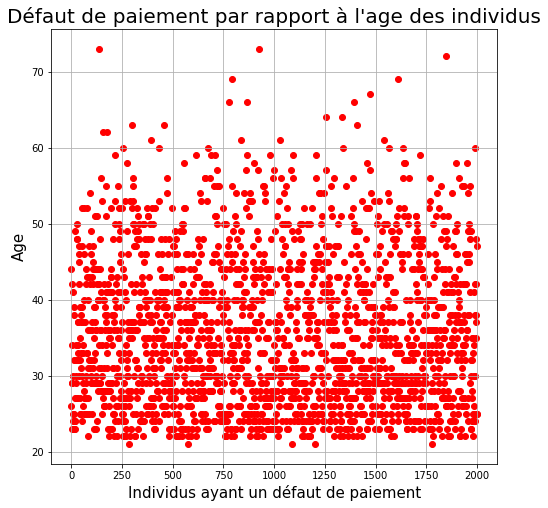

```python
datacopy = data.loc[data["default payment next month"] == 1,:] # On prends que les lignes qui ont un défaut de paiement
display_scatter_plot(datacopy["AGE"], 2000, "Défaut de paiement par rapport à l'age des individus", "Individus ayant un défaut de paiement", "Age")
```

Nous constatons que il y'a des défauts de paiements pour les individus de tout âge.

## Densité des montants

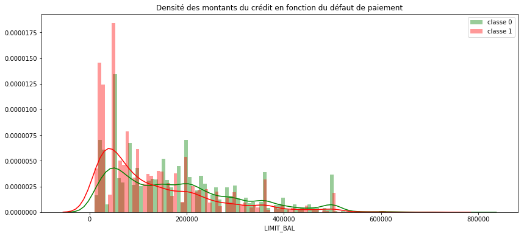

```python
import seaborn as sns
class_0 = data.loc[data['default payment next month'] == 0]["LIMIT_BAL"]
class_1 = data.loc[data['default payment next month'] == 1]["LIMIT_BAL"]
plt.figure(figsize = (14,6))
plt.title('Densité des montants du crédit en fonction du défaut de paiement')
sns.set_color_codes("pastel")
sns.distplot(class_0,kde=True,bins=100, color="green")
sns.distplot(class_1,kde=True,bins=100, color="red")
plt.legend(['classe 0','classe 1'])
plt.show()
```

Nous voyons sur ce graphique que les individus ayant un défaut de paiement ont tendance à avoir des montants de crédit moins élevés que les autres individus. Nous observons des pics de densité sur les montants à **50 000**, **30 000** et **20 000**

## Sexe des individus

```python
dataFemme = data.loc[data["SEX"]==2,:]
dataHomme = data.loc[data["SEX"]==1,:]
print("Nombre de femmes qui ont eu un défaut de paiement : " + str(sum(dataFemme["default payment next month"])))
print("Nombre d'hommes qui ont eu un défaut de paiement : " + str(sum(dataHomme["default payment next month"])))
```

```
Nombre de femmes qui ont eu un défaut de paiement : 2514
Nombre d'hommes qui ont eu un défaut de paiement : 1890
```

## Education et Montants des crédits

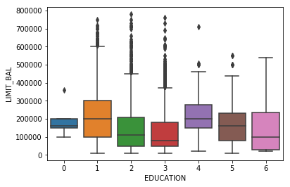

```python
sns.boxplot(x=data['EDUCATION'],y=data['LIMIT_BAL'])
```

Sur ce graphique on s'aperçoit que la médiane des montants de crédits pris par les individus ayant un niveau d'éducation bac+5 ou plus est plus élevé que les montants des autres classes d'éducation

# Division du jeu de données

```python
#Variables à créer: X_train, Y_train, X_test, Y_test
from sklearn.model_selection import train_test_split
y = data['default payment next month']
x = data.drop('default payment next month', axis=1)
X_train, X_test, y_train, y_test = train_test_split(x, y, test_size = 0.20, random_state=0)
```

Nous avons 80 % du dataset consacré à l'apprentissage et 20% pour le test.

# Premier test d'apprentissage

Pour ce problème, nous avons fait le choix de partir sur une **classification binaire supervisée**.

Comme mesure de validation, nous avons choisi de prioriser l'**AUC** car on veut que notre modèle prédise le plus possible les individus ayant un défaut de paiement parmi tous ceux labélisés comme tel.

Nous avons décidé de lancer quelques classifieurs pour voir les axes d'amélioration du modèle de base.

## Linear SVC

```
Confusion matrix, without normalization
[[3079    1]
 [ 920    0]]
              precision    recall  f1-score   support

           0       0.77      1.00      0.87      3080
           1       0.00      0.00      0.00       920

   micro avg       0.77      0.77      0.77      4000
   macro avg       0.38      0.50      0.43      4000
weighted avg       0.59      0.77      0.67      4000

AUC : 0.49983766233766236
Score du modèle : 0.76975
```

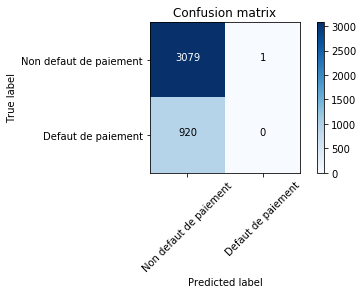

```python
clf = LinearSVC()
clf.fit(X_train, y_train)
y_pred = clf.predict(X_test)
cm = confusion_matrix(y_test, y_pred)
plot_confusion_matrix(cm, ['Non defaut de paiement', 'Defaut de paiement'])
print(classification_report(y_test, y_pred))
print("AUC : " + str(roc_auc_score(y_test, y_pred)))
print("Score du modèle : " + str(clf.score(X_test, y_test)))
```

Le **LinearSVC** parvient à très bien prédire les non défaut de paiment, mais il se trompe très souvent pour l'autre classe.

## KNeighbors Classifier

Pour ce modèle, il nous faut trouver un bon K. C'est pour cela que nous utilisons le grid search sur le paramètre `n_neighbors`

```python
from sklearn.model_selection import GridSearchCV
param_grid = {
  'n_neighbors' : range(1,10)
}
gd = GridSearchCV(KNeighborsClassifier(), param_grid, cv=3, n_jobs=-1, verbose=2)
gd.fit(X_train, y_train)
```

```
Fitting 3 folds for each of 9 candidates, totalling 27 fits
```

```
[Parallel(n_jobs=-1)]: Using backend LokyBackend with 4 concurrent workers.
[Parallel(n_jobs=-1)]: Done  27 out of  27 | elapsed:   17.4s finished
```

```
GridSearchCV(cv=3, error_score='raise-deprecating',
       estimator=KNeighborsClassifier(algorithm='auto', leaf_size=30, metric='minkowski',
           metric_params=None, n_jobs=None, n_neighbors=5, p=2,
           weights='uniform'),
       fit_params=None, iid='warn', n_jobs=-1,
       param_grid={'n_neighbors': range(1, 10)}, pre_dispatch='2*n_jobs',
       refit=True, return_train_score='warn', scoring=None, verbose=2)
```

```python
# Meilleur k
gd.best_params_
```

```
{'n_neighbors': 8}
```

```python
knn = KNeighborsClassifier(n_neighbors=1)
```

```
Confusion matrix, without normalization
[[2481  599]
 [ 657  263]]
              precision    recall  f1-score   support

           0       0.79      0.81      0.80      3080
           1       0.31      0.29      0.30       920

   micro avg       0.69      0.69      0.69      4000
   macro avg       0.55      0.55      0.55      4000
weighted avg       0.68      0.69      0.68      4000

AUC : 0.5456945228684359
Score du modèle : 0.686
```

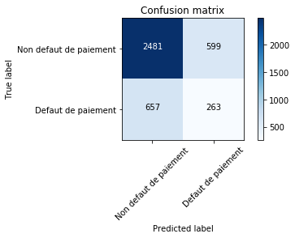

```python
knn.fit(X_train, y_train)
y_pred = knn.predict(X_test)
cm = confusion_matrix(y_test, y_pred)
plot_confusion_matrix(cm, ['Non defaut de paiement', 'Defaut de paiement'])
print(classification_report(y_test, y_pred))
print("AUC : " + str(roc_auc_score(y_test, y_pred)))
print("Score du modèle : " + str(knn.score(X_test, y_test)))
```

Les résultats du **KNN** sont semblables à ceux du **LinearSVC**, nous allons tester avec un **RandomForest**

## Random Forest

```
Confusion matrix, without normalization
[[2921  159]
 [ 564  356]]
              precision    recall  f1-score   support

           0       0.84      0.95      0.89      3080
           1       0.69      0.39      0.50       920

   micro avg       0.82      0.82      0.82      4000
   macro avg       0.76      0.67      0.69      4000
weighted avg       0.80      0.82      0.80      4000

AUC : 0.6676665725578768
Score du modèle : 0.81925
```

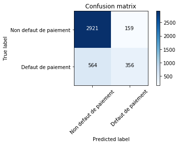

```python
rf = RandomForestClassifier(n_estimators=100)
rf.fit(X_train,y_train)
y_pred = rf.predict(X_test)
cm = confusion_matrix(y_test, y_pred)
plot_confusion_matrix(cm, ['Non defaut de paiement', 'Defaut de paiement'])
print(classification_report(y_test, y_pred))
print("AUC : " + str(roc_auc_score(y_test, y_pred)))
print("Score du modèle : " + str(rf.score(X_test, y_test)))
```

Nous proposone de binariser les variables qualitatif et réessayer une RF.

### Binarisation des variables

Nous allons binariser les différentes variables qualitatives du jeu de données avec la fonction get_dummies

```python
cat_features = ['EDUCATION', 'SEX', 'MARRIAGE', 'PAY_0', 'PAY_2', 'PAY_3', 'PAY_4', 'PAY_5', 'PAY_6']
x_dummies = pd.get_dummies(data.drop('default payment next month',axis=1), columns = cat_features)
x_dummies = x_dummies.drop('EDUCATION_5', axis=1).drop('PAY_0_0', axis=1).drop('PAY_2_0', axis=1).drop('PAY_3_0', axis=1).drop('PAY_4_0', axis=1).drop('PAY_5_0', axis=1).drop('PAY_6_0', axis=1).drop('MARRIAGE_3', axis=1).drop('SEX_1', axis=1)
```

```python
#Variables à créer: X_train, Y_train, X_test, Y_test
from sklearn.model_selection import train_test_split
X_train_dummies, X_test_dummies, y_train_dummies, y_test_dummies = train_test_split(x_dummies, y, test_size = 0.20)
```

```
Confusion matrix, without normalization
[[2929  173]
 [ 569  329]]
              precision    recall  f1-score   support

           0       0.84      0.94      0.89      3102
           1       0.66      0.37      0.47       898

   micro avg       0.81      0.81      0.81      4000
   macro avg       0.75      0.66      0.68      4000
weighted avg       0.80      0.81      0.79      4000

AUC : 0.6552996199018091
Score du modèle : 0.8145
```

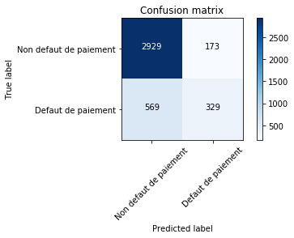

```python
rf = RandomForestClassifier(n_estimators=100)
rf.fit(X_train_dummies,y_train_dummies)
y_pred_dummies = rf.predict(X_test_dummies)
cm = confusion_matrix(y_test_dummies, y_pred_dummies)
plot_confusion_matrix(cm, ['Non defaut de paiement', 'Defaut de paiement'])
print(classification_report(y_test_dummies, y_pred_dummies))
print("AUC : " + str(roc_auc_score(y_test_dummies, y_pred_dummies)))
print("Score du modèle : " + str(rf.score(X_test_dummies, y_test_dummies)))
```

On peut voir ici que la binarisation n'a apporté aucune evolution à notre modèle précédent.

Après analyse des données, nous nous aperçevons qu'il n'y a que 22% de données qui ont un défaut de paiement, c'est assez peu pour faire apprendre notre modèle.

```python
print("Pourcentage de défaut de paiement dans notre dataset : " + str(sum(data['default payment next month'])/len(data['default payment next month'])*100) +" %")
```

```
Pourcentage de défaut de paiement dans notre dataset : 22.02 %
```

On décide donc de chercher une méthode d'oversampling afin d'homogénéiser notre dataset.

### OverSampling

#### Smote

```python
from imblearn.over_sampling import SMOTE
sm = SMOTE(random_state=2)
X_train_res, y_train_res = sm.fit_sample(X_train, y_train.ravel())
```

```python
print("Pourcentage de défaut de paiement dans notre dataset : " + str(sum(y_train_res)/len(y_train_res)*100) +" %")
```

```
Pourcentage de défaut de paiement dans notre dataset : 50.0 %
```

Retestons notre modèle avec ces nouvelles données.

```
Confusion matrix, without normalization
[[2692  388]
 [ 442  478]]
              precision    recall  f1-score   support

           0       0.86      0.87      0.87      3080
           1       0.55      0.52      0.54       920

   micro avg       0.79      0.79      0.79      4000
   macro avg       0.71      0.70      0.70      4000
weighted avg       0.79      0.79      0.79      4000

AUC : 0.6967955957086391
Score du modèle : 0.7925
```

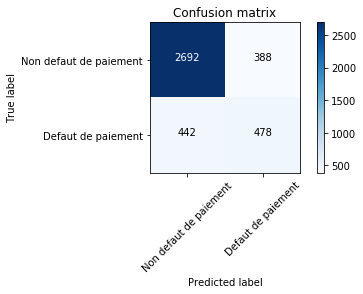

```python
rf = RandomForestClassifier(n_estimators=100)
rf.fit(X_train_res,y_train_res)
y_pred = rf.predict(X_test)
cm = confusion_matrix(y_test, y_pred)
plot_confusion_matrix(cm, ['Non defaut de paiement', 'Defaut de paiement'])
print(classification_report(y_test, y_pred))
print("AUC : " + str(roc_auc_score(y_test, y_pred)))
print("Score du modèle : " + str(rf.score(X_test, y_test)))
```

Nous constatons que l'over sampling a porté ses fruits et nous a permis d'augmenter notre AUC et mieux prédire les défauts de paiement (On prédit bien un défaut de paiement environ une fois sur deux)

# Optimisation

### Grid Search

```python
param_grid = {
    'bootstrap': [True],
    'max_depth': [80],
    'max_features': [3],
    'min_samples_leaf': [3],
    'min_samples_split': [8],
    'n_estimators': [1000],
    'criterion':('gini','entropy')
}
gd = GridSearchCV(RandomForestClassifier(), param_grid, cv=3, n_jobs=-1, verbose=2)
gd.fit(X_train_res, y_train_res)
```

```
Fitting 3 folds for each of 2 candidates, totalling 6 fits
```

```
[Parallel(n_jobs=-1)]: Using backend LokyBackend with 4 concurrent workers.
[Parallel(n_jobs=-1)]: Done   3 out of   6 | elapsed:  1.1min remaining:  1.1min
[Parallel(n_jobs=-1)]: Done   6 out of   6 | elapsed:  2.0min finished
```

```
GridSearchCV(cv=3, error_score='raise-deprecating',
       estimator=RandomForestClassifier(bootstrap=True, class_weight=None, criterion='gini',
            max_depth=None, max_features='auto', max_leaf_nodes=None,
            min_impurity_decrease=0.0, min_impurity_split=None,
            min_samples_leaf=1, min_samples_split=2,
            min_weight_fraction_leaf=0.0, n_estimators='warn', n_jobs=None,
            oob_score=False, random_state=None, verbose=0,
            warm_start=False),
       fit_params=None, iid='warn', n_jobs=-1,
       param_grid={'bootstrap': [True], 'max_depth': [80], 'max_features': [3], 'min_samples_leaf': [3], 'min_samples_split': [8], 'n_estimators': [1000], 'criterion': ('gini', 'entropy')},
       pre_dispatch='2*n_jobs', refit=True, return_train_score='warn',
       scoring=None, verbose=2)
```

```python
gd.best_params_
```

```
{'bootstrap': True,
 'criterion': 'entropy',
 'max_depth': 80,
 'max_features': 3,
 'min_samples_leaf': 3,
 'min_samples_split': 8,
 'n_estimators': 1000}
```

Le GridSearch nous a généré le "meilleur modèle" pour ce jeu de donnée, on reteste notre modèle avec ces paramètres.  
**Petite précision**: nous avons fait le gridSearch sur plusieurs paramètres et nous avons pris les meilleurs paramètres ici nous testons juste le méta paramètre criterion. Le premier GridSearch nous a pris 1h à peu près.

```
Confusion matrix, without normalization
[[2669  411]
 [ 414  506]]
              precision    recall  f1-score   support

           0       0.87      0.87      0.87      3080
           1       0.55      0.55      0.55       920

   micro avg       0.79      0.79      0.79      4000
   macro avg       0.71      0.71      0.71      4000
weighted avg       0.79      0.79      0.79      4000

AUC : 0.7082792207792208
Score du modèle : 0.79375
```

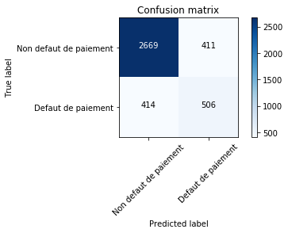

```python
rf = RandomForestClassifier(criterion='entropy',
                            n_estimators=1000,
                            bootstrap=True,
                            max_depth=80,
                            max_features=3,
                            min_samples_leaf=3,
                            min_samples_split=8)
rf.fit(X_train_res,y_train_res)
y_pred = rf.predict(X_test)
cm = confusion_matrix(y_test, y_pred)
plot_confusion_matrix(cm, ['Non defaut de paiement', 'Defaut de paiement'])
print(classification_report(y_test, y_pred))
print("AUC : " + str(roc_auc_score(y_test, y_pred)))
print("Score du modèle : " + str(rf.score(X_test, y_test)))
```

Voici le modèle optimal que nous pouvons avoir avec le Random Forest, nous avons un recall meilleur sur les prédictions de defaut de paiement.

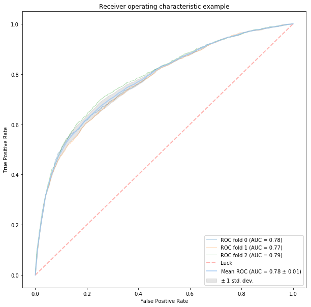

```python
from sklearn.metrics import roc_curve, auc
from sklearn.model_selection import StratifiedKFold
from scipy import interp

# Classification and ROC analysis
random_state = 42
# Run classifier with cross-validation and plot ROC curves
cv = StratifiedKFold(n_splits=3)
classifier = RandomForestClassifier(criterion='entropy',n_estimators=1000,bootstrap=True, max_depth=90, max_features=3, min_samples_leaf=3,min_samples_split=8)

tprs = []
aucs = []
mean_fpr = np.linspace(0, 1, 100)
plt.figure(figsize=(10,10))
i = 0
for train, test in cv.split(x, y):
    clf = classifier.fit(x.loc[train], y.loc[train])
    probas_ =  clf.predict_proba(x.loc[test])
    # Compute ROC curve and area the curve
    fpr, tpr, thresholds = roc_curve(y.loc[test], probas_[:, 1])
    tprs.append(interp(mean_fpr, fpr, tpr))
    tprs[-1][0] = 0.0
    roc_auc = auc(fpr, tpr)
    aucs.append(roc_auc)
    plt.plot(fpr, tpr, lw=1, alpha=0.3,
             label='ROC fold %d (AUC = %0.2f)' % (i, roc_auc))

    i += 1
plt.plot([0, 1], [0, 1], linestyle='--', lw=2, color='r',
         label='Luck', alpha=.8)

mean_tpr = np.mean(tprs, axis=0)
mean_tpr[-1] = 1.0
mean_auc = auc(mean_fpr, mean_tpr)
std_auc = np.std(aucs)
plt.plot(mean_fpr, mean_tpr, color='b',
         label=r'Mean ROC (AUC = %0.2f $\pm$ %0.2f)' % (mean_auc, std_auc),
         lw=2, alpha=.8)

std_tpr = np.std(tprs, axis=0)
tprs_upper = np.minimum(mean_tpr + std_tpr, 1)
tprs_lower = np.maximum(mean_tpr - std_tpr, 0)
plt.fill_between(mean_fpr, tprs_lower, tprs_upper, color='grey', alpha=.2,
                 label=r'$\pm$ 1 std. dev.')

plt.xlim([-0.05, 1.05])
plt.ylim([-0.05, 1.05])
plt.xlabel('False Positive Rate')
plt.ylabel('True Positive Rate')
plt.title('Receiver operating characteristic example')
plt.legend(loc="lower right")
plt.show()
```

Visualison maintenant les variables les plus importantes de notre modèle

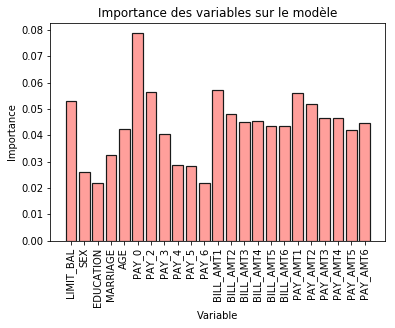

```python
importances = list(rf.feature_importances_)
x_values = list(range(len(importances)))
plt.bar(x_values, importances, orientation = 'vertical', color = 'r', edgecolor = 'k', linewidth = 1.2)
plt.xticks(x_values, x, rotation='vertical')
plt.ylabel('Importance'); plt.xlabel('Variable'); plt.title('Importance des variables sur le modèle');
```

Grâce au graphique des *features_importances* nous constatons que la variable `PAY_0`, `LIMIT_BAL` et l'ensemble des `BILL_AMT` influencent le plus contrairement aux variables qualitatives `SEX`, `EDUCATION` et `MARRIAGE`.

# GradientBoostingClassifier

Nous avons vu en cours qu'il existait un classifieur assez performant au nom de `GradientBoosting`, on décide de l'utiliser pour notre dataset

```
Confusion matrix, without normalization
[[2537  543]
 [ 381  539]]
              precision    recall  f1-score   support

           0       0.87      0.82      0.85      3080
           1       0.50      0.59      0.54       920

   micro avg       0.77      0.77      0.77      4000
   macro avg       0.68      0.70      0.69      4000
weighted avg       0.78      0.77      0.78      4000

AUC : 0.704785431959345
Score du modèle : 0.769
```

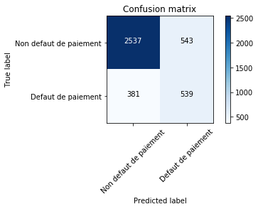

```python
gbc = GradientBoostingClassifier()
gbc.fit(X_train_res,y_train_res)
y_pred = gbc.predict(X_test)
cm = confusion_matrix(y_test, y_pred)
plot_confusion_matrix(cm, ['Non defaut de paiement', 'Defaut de paiement'])
print(classification_report(y_test, y_pred))
print("AUC : " + str(roc_auc_score(y_test, y_pred)))
print("Score du modèle : " + str(gbc.score(X_test, y_test)))
```

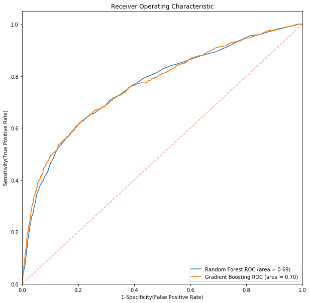

```python
from sklearn import metrics
import matplotlib.pyplot as plt

plt.figure(figsize=(10,10))


# Add the models to the list that you want to view on the ROC plot
models = [
{
    'label': 'Random Forest',
    'model': RandomForestClassifier(n_estimators=100),
},
{
    'label': 'Gradient Boosting',
    'model': GradientBoostingClassifier(),
}
]

# Below for loop iterates through your models list
for m in models:
    model = m['model'] # select the model
    model.fit(X_train_res, y_train_res) # train the model
    y_pred=model.predict(X_test) # predict the test data
# Compute False postive rate, and True positive rate
    fpr, tpr, thresholds = metrics.roc_curve(y_test, model.predict_proba(X_test)[:,1])
# Calculate Area under the curve to display on the plot
    auc = metrics.roc_auc_score(y_test,model.predict(X_test))
# Now, plot the computed values
    plt.plot(fpr, tpr, label='%s ROC (area = %0.2f)' % (m['label'], auc))
# Custom settings for the plot
plt.plot([0, 1], [0, 1],'r--')
plt.xlim([0.0, 1.0])
plt.ylim([0.0, 1.05])
plt.xlabel('1-Specificity(False Positive Rate)')
plt.ylabel('Sensitivity(True Positive Rate)')
plt.title('Receiver Operating Characteristic')
plt.legend(loc="lower right")
plt.show()   # Display
```

Nous observons que ce modèle est plus performant que le **Random Forest** sans optimisation de paramètres (GridSearch). En effet, l'AUC du RF était de : **0.69** vs **0.70** pour le GradientBoosting

# Perspectives d'amélioration

```python
misclassified_samples = X_test[y_test != y_pred]
misclassified_samples
```

|  | LIMIT_BAL | SEX | EDUCATION | MARRIAGE | AGE | PAY_0 | PAY_2 | PAY_3 | PAY_4 | PAY_5 | ... | BILL_AMT3 | BILL_AMT4 | BILL_AMT5 | BILL_AMT6 | PAY_AMT1 | PAY_AMT2 | PAY_AMT3 | PAY_AMT4 | PAY_AMT5 | PAY_AMT6 |
| --- | --- | --- | --- | --- | --- | --- | --- | --- | --- | --- | --- | --- | --- | --- | --- | --- | --- | --- | --- | --- | --- |
| 5306 | 80000 | 2 | 2 | 2 | 24 | 1 | 1 | -1 | -1 | -1 | ... | 10000 | 18150 | 7490 | 7490 | 10000 | 10000 | 18150 | 7490 | 7490 | 7490 |
| 230 | 80000 | 2 | 1 | 2 | 25 | -1 | 2 | 2 | -2 | -2 | ... | 0 | 0 | 0 | 0 | 0 | 0 | 0 | 0 | 0 | 0 |
| 13672 | 510000 | 1 | 3 | 2 | 31 | 1 | -1 | 0 | 0 | 0 | ... | 17023 | 9706 | 7271 | 9551 | 14370 | 3500 | 2500 | 1380 | 2380 | 3000 |
| 6518 | 110000 | 2 | 2 | 1 | 46 | 0 | -1 | -1 | -1 | -1 | ... | 2151 | 2161 | 1719 | 107591 | 2410 | 2151 | 2161 | 1719 | 107591 | 5000 |
| 19197 | 60000 | 1 | 2 | 1 | 41 | 0 | 0 | 0 | 0 | 0 | ... | 29347 | 19544 | 11989 | 9079 | 5070 | 1219 | 1007 | 8 | 9381 | 1156 |
| 16663 | 180000 | 1 | 2 | 1 | 30 | 0 | 0 | 0 | 0 | 0 | ... | 134817 | 52629 | 51543 | 52781 | 6100 | 6000 | 1900 | 1680 | 1900 | 3888 |
| 17114 | 30000 | 2 | 3 | 1 | 47 | 1 | 2 | 2 | 2 | 0 | ... | 13892 | 14369 | 15333 | 16289 | 1000 | 900 | 1000 | 1200 | 1200 | 1200 |
| 12941 | 230000 | 2 | 1 | 1 | 31 | -1 | -1 | -2 | -1 | -1 | ... | 0 | 1100 | 0 | 1383 | 0 | 0 | 1100 | 0 | 1383 | 905 |
| 5739 | 390000 | 1 | 5 | 2 | 29 | 1 | 2 | 0 | 0 | 0 | ... | 395333 | 367400 | 304990 | 304303 | 0 | 14414 | 14411 | 76000 | 15000 | 13000 |
| 17037 | 130000 | 2 | 1 | 2 | 27 | 1 | -2 | -1 | 2 | 2 | ... | 98 | 98 | 98 | 2500 | 0 | 98 | 0 | 0 | 2500 | 0 |
| 4872 | 100000 | 1 | 1 | 1 | 43 | 0 | 0 | 0 | 0 | 0 | ... | 45522 | 46832 | 37683 | 28680 | 2100 | 3000 | 2500 | 2000 | 2000 | 2000 |
| 3319 | 150000 | 2 | 2 | 1 | 31 | 2 | 0 | 0 | 0 | 0 | ... | 108229 | 109374 | 111279 | 125353 | 3872 | 5500 | 4005 | 3241 | 15500 | 4000 |
| 12949 | 240000 | 2 | 2 | 2 | 28 | 2 | 2 | 2 | 2 | 0 | ... | 276585 | 253679 | 232300 | 212749 | 0 | 22550 | 0 | 8450 | 7800 | 6975 |
| 10346 | 170000 | 2 | 2 | 2 | 28 | -1 | 0 | 0 | 2 | 0 | ... | 5646 | 5464 | 5577 | 5889 | 1105 | 1903 | 0 | 296 | 500 | 95 |
| 19557 | 50000 | 2 | 3 | 1 | 45 | 0 | 0 | 0 | 0 | 0 | ... | 6184 | 7194 | 7336 | 7490 | 1088 | 1110 | 1120 | 262 | 272 | 273 |
| 18697 | 50000 | 1 | 2 | 1 | 53 | 0 | 0 | 0 | 0 | 0 | ... | 51131 | 49099 | 19739 | 19905 | 1998 | 2374 | 1130 | 523 | 537 | 633 |
| 9737 | 180000 | 1 | 2 | 2 | 30 | 0 | 0 | 0 | 2 | 0 | ... | 36882 | 34000 | 34798 | 35488 | 1581 | 4626 | 0 | 1500 | 1419 | 1400 |
| 6810 | 240000 | 2 | 2 | 1 | 40 | -1 | -1 | -1 | -1 | -1 | ... | 390 | 390 | 232 | 540 | 390 | 390 | 390 | 232 | 698 | 390 |
| 385 | 80000 | 1 | 1 | 2 | 29 | -1 | -1 | 2 | 0 | 0 | ... | 1863 | 3309 | 1446 | 390 | 4599 | 0 | 1446 | 0 | 0 | 2493 |
| 5211 | 50000 | 2 | 2 | 1 | 39 | 3 | 2 | 2 | -2 | -2 | ... | -350 | -350 | -350 | -350 | 0 | 350 | 0 | 0 | 0 | 0 |
| 9601 | 10000 | 2 | 3 | 1 | 41 | -1 | 2 | -1 | -1 | 2 | ... | 172 | 2034 | 2069 | 1891 | 0 | 179 | 2034 | 214 | 0 | 283 |
| 12047 | 240000 | 2 | 1 | 1 | 27 | 1 | -2 | -1 | -1 | 0 | ... | 402 | 14350 | 14129 | 10222 | 0 | 402 | 14350 | 1129 | 1222 | 204 |
| 12482 | 180000 | 1 | 2 | 1 | 28 | 0 | 0 | 0 | 0 | 2 | ... | 156334 | 165696 | 165582 | 168952 | 6000 | 8000 | 13500 | 4110 | 6200 | 13600 |
| 15967 | 80000 | 2 | 3 | 1 | 28 | 0 | 0 | 0 | 0 | 0 | ... | 66171 | 58683 | 43421 | 44267 | 3000 | 2470 | 2228 | 1516 | 2000 | 1556 |
| 11248 | 140000 | 2 | 1 | 2 | 27 | 1 | -1 | -1 | -1 | -2 | ... | 446 | 0 | 0 | 0 | 2051 | 446 | 0 | 0 | 0 | 1593 |
| 17567 | 130000 | 1 | 2 | 1 | 33 | -1 | -1 | -1 | -1 | -1 | ... | 99 | 99 | 99 | 98 | 99 | 99 | 99 | 99 | 98 | 894 |
| 18044 | 10000 | 1 | 2 | 2 | 21 | 0 | 0 | -2 | -2 | -2 | ... | 0 | 0 | 0 | 0 | 0 | 0 | 0 | 0 | 0 | 0 |
| 12407 | 20000 | 1 | 1 | 1 | 34 | 2 | 0 | 0 | 2 | 2 | ... | 8989 | 8436 | 12016 | 11404 | 2000 | 2000 | 0 | 4000 | 0 | 4000 |
| 5370 | 120000 | 1 | 3 | 2 | 28 | -1 | 3 | 2 | -1 | -1 | ... | 390 | 390 | 282 | -108 | 0 | 0 | 390 | 282 | 0 | 3087 |
| 717 | 60000 | 2 | 3 | 1 | 48 | 0 | 0 | 0 | 0 | 0 | ... | 53377 | 37418 | 37543 | 35447 | 2500 | 2000 | 1900 | 1500 | 1300 | 1300 |
| ... | ... | ... | ... | ... | ... | ... | ... | ... | ... | ... | ... | ... | ... | ... | ... | ... | ... | ... | ... | ... | ... |
| 13005 | 150000 | 2 | 1 | 2 | 30 | 1 | -2 | -2 | -2 | -1 | ... | 0 | 0 | 1883 | 1883 | 0 | 0 | 0 | 1883 | 0 | 0 |
| 14155 | 160000 | 2 | 2 | 2 | 25 | 1 | -1 | 0 | 0 | 0 | ... | 2043 | 3133 | 0 | 0 | 1000 | 1043 | 1133 | 0 | 0 | 7482 |
| 7519 | 360000 | 2 | 1 | 2 | 29 | -1 | -1 | -1 | -2 | -2 | ... | 0 | 0 | 0 | 0 | 2500 | 0 | 0 | 0 | 0 | 0 |
| 11615 | 100000 | 1 | 2 | 2 | 31 | 1 | 2 | 0 | 0 | 0 | ... | 90519 | 80051 | 76446 | 76815 | 0 | 3631 | 3000 | 3000 | 2800 | 2697 |
| 18927 | 60000 | 2 | 1 | 2 | 30 | 1 | 2 | 2 | 2 | 2 | ... | 43153 | 43845 | 44795 | 45710 | 400 | 3406 | 1700 | 1800 | 1800 | 0 |
| 6529 | 120000 | 1 | 3 | 1 | 49 | 0 | -1 | -1 | -1 | -1 | ... | 2290 | 780 | 8190 | 4600 | 3844 | 2299 | 780 | 8190 | 4600 | 1081 |
| 1358 | 140000 | 2 | 1 | 2 | 25 | -1 | 0 | 0 | 0 | 0 | ... | 6259 | 7115 | 8135 | 1459 | 2000 | 2000 | 1000 | 1020 | 100 | 2500 |
| 12810 | 20000 | 1 | 2 | 2 | 23 | 1 | 2 | 2 | 2 | 2 | ... | 6181 | 6778 | 6524 | 8408 | 2000 | 0 | 700 | 0 | 2000 | 2000 |
| 6675 | 50000 | 1 | 2 | 1 | 46 | 0 | 0 | 0 | 0 | 0 | ... | 34440 | 30889 | 30182 | 29912 | 2000 | 2500 | 2000 | 1500 | 5000 | 1500 |
| 17678 | 150000 | 1 | 2 | 2 | 49 | 0 | 0 | 0 | 0 | 0 | ... | 75782 | 76333 | 77956 | 77553 | 2985 | 2700 | 5000 | 2823 | 2865 | 2679 |
| 5924 | 450000 | 1 | 1 | 1 | 33 | -1 | -1 | -1 | -1 | -1 | ... | 390 | 390 | 389 | 990 | 390 | 390 | 390 | 389 | 992 | 780 |
| 6605 | 30000 | 2 | 3 | 2 | 53 | -1 | -1 | -1 | -1 | -1 | ... | 0 | 4810 | 2796 | 3245 | 2487 | 0 | 4810 | 2796 | 3245 | 7305 |
| 17561 | 20000 | 1 | 1 | 1 | 50 | 0 | 0 | -2 | -2 | -2 | ... | 0 | 0 | 0 | 0 | 0 | 50000 | 0 | 1300 | 0 | 0 |
| 14250 | 50000 | 2 | 2 | 2 | 52 | 0 | 0 | 0 | 0 | 0 | ... | 15843 | 16825 | 14637 | 15397 | 2000 | 1400 | 2000 | 5000 | 1000 | 1000 |
| 1205 | 120000 | 2 | 3 | 2 | 25 | 0 | 0 | 0 | 0 | 0 | ... | 107838 | 103273 | 101353 | 87934 | 4000 | 5013 | 4000 | 3199 | 3130 | 4000 |
| 1603 | 20000 | 2 | 2 | 2 | 38 | 1 | 2 | 2 | 4 | 3 | ... | 14734 | 14190 | 13721 | 13848 | 2500 | 2501 | 0 | 0 | 441 | 1 |
| 2111 | 320000 | 1 | 1 | 1 | 43 | -1 | -1 | -1 | 0 | 0 | ... | 14857 | 12157 | 8690 | 4166 | 86682 | 14871 | 260 | 43 | 4186 | 904 |
| 10124 | 290000 | 1 | 1 | 2 | 35 | -2 | -2 | -2 | -2 | -2 | ... | 97606 | 76053 | 53994 | 31812 | 4166 | 3400 | 2588 | 1696 | 1113 | 1647 |
| 8714 | 500000 | 1 | 1 | 2 | 42 | -2 | -2 | -2 | -2 | -2 | ... | 0 | 0 | 0 | 0 | 0 | 0 | 0 | 0 | 0 | 0 |
| 19924 | 360000 | 1 | 1 | 1 | 54 | 1 | -1 | -1 | -1 | -1 | ... | 7508 | 434 | 2139 | 993 | 3011 | 7545 | 502 | 2205 | 5 | 1799 |
| 15833 | 140000 | 1 | 1 | 2 | 29 | 1 | -2 | -2 | -2 | -2 | ... | 0 | 0 | 0 | 0 | 0 | 0 | 0 | 0 | 0 | 0 |
| 4263 | 40000 | 1 | 2 | 1 | 47 | 1 | 2 | 2 | 3 | 2 | ... | 40985 | 40085 | 39354 | 40322 | 0 | 4898 | 0 | 0 | 1800 | 3000 |
| 7613 | 90000 | 2 | 2 | 2 | 23 | 1 | 3 | 2 | 0 | 0 | ... | 36654 | 32747 | 33091 | 33291 | 0 | 15 | 1831 | 1175 | 1338 | 1216 |
| 5708 | 120000 | 2 | 2 | 2 | 29 | -2 | -2 | -2 | -2 | -2 | ... | 0 | 0 | 0 | 0 | 0 | 0 | 0 | 0 | 0 | 6330 |
| 6793 | 180000 | 2 | 1 | 1 | 28 | 1 | -2 | -2 | -2 | -2 | ... | 0 | 0 | 0 | 0 | 0 | 0 | 0 | 0 | 0 | 0 |
| 1333 | 50000 | 1 | 3 | 1 | 52 | 0 | 0 | 0 | 0 | 0 | ... | 49063 | 16908 | 13112 | 2280 | 2200 | 2343 | 1178 | 654 | 2280 | 390 |
| 3263 | 300000 | 2 | 2 | 1 | 33 | 1 | -2 | -2 | -2 | -2 | ... | 0 | 0 | 0 | 0 | 0 | 0 | 0 | 0 | 0 | 0 |
| 14043 | 310000 | 1 | 2 | 1 | 39 | 0 | 0 | 0 | 0 | 0 | ... | 233854 | 219409 | 216540 | 210675 | 10029 | 9218 | 10029 | 8049 | 8040 | 10059 |
| 19142 | 10000 | 1 | 2 | 2 | 47 | -1 | -1 | -1 | -1 | -1 | ... | 9797 | -10433 | 9767 | 9067 | 10400 | 1000 | 0 | 20200 | 200 | 0 |
| 18899 | 240000 | 2 | 1 | 2 | 26 | 1 | -2 | -2 | -2 | -2 | ... | 0 | 0 | 0 | 0 | 0 | 0 | 0 | 0 | 0 | 0 |

924 rows × 23 columns

Voici les lignes sur les quelles notre modèle a fait une erreur.  
Nous constatons que parmi ces lignes, beaucoup ont des valeurs `0`.  
Parmi les perspectives d'amélioration, nous pourrions supprimer les lignes contenant trop de zéro, selon un seuil défini. Il faut cependant faire attention à ne pas trop spécifier notre apprentissage pour éviter l`overfitting`

On peut améliorer notre modèle (GradientBoosting) en optimisant les paramètres avec un GridSearch. On pourrait alors comparer avec le RF optimisé pour voir si le GradientBoosting est vraiment meilleur. Par manque de temps, nous n'avons pas pu réaliser l'optimisation des paramètres pour ce modèle.

# Conclusion

Ce projet nous a permis de rencontrer des données plus réalistes de ce que nous avons vu en cours, la problématique de ce projet était de trouver un modèle correct en prévision de défaut de paiement mais aussi un modèle avec un score correct.  
Nous pensons que nous avons réussi à trouver un modèle qui répondait assez bien à notre problématique. Nous vous remercions de ce projet qui nous a permis de nous mettre à la place de futurs Data Scientists et nous a illustré les problèmes réalistes d'un projet DataScience.